# Comparing the Matched Data to the Initial Data - Cruise Experiment

Comparing days with one cruise vessels entering the port to days without. Adjusting for calendar and weather indicators.

In this document, we take great care providing all steps and R codes required to compare the matched data to the initial data. We compare days where:

- treated units are days with one cruise vessel entering the port in *t*.
- control units are day with zero cruise vessel entering the port in *t*.

We adjust for calendar indicator and weather confouding factors.

**Should you have any questions, need help to reproduce the analysis or find coding errors, please do not hesitate to contact us at leo.zabrocki@psemail.eu and marion.leroutier@hhs.se.**

# Required Packages

To reproduce exactly the `2_script_comparing_two_datasets.html` document, we first need to have installed:

- the [R](https://www.r-project.org/) programming language
- [RStudio](https://rstudio.com/), an integrated development environment for R, which will allow you to knit the `2_script_comparing_two_datasets.Rmd` file and interact with the R code chunks
- the [R Markdown](https://rmarkdown.rstudio.com/) package
- and the [Distill](https://rstudio.github.io/distill/) package which provides the template for this document.

Once everything is set up, we have to load the following packages:

```r
# load required packages
library(knitr) # for creating the R Markdown document
library(here) # for files paths organization
library(tidyverse) # for data manipulation and visualization
library(ggridges) # for ridge density plots
library(kableExtra) # for table formatting
library(Cairo) # for printing customed police of graphs
library(patchwork) # combining plots
```

We finally load our customed `ggplot2` theme for graphs:

```r
# load ggplot customed theme
source(here::here("2.scripts", "5.custom_ggplot2_theme", "script_custom_ggplot_theme.R"))
```

The theme is based on the fantastic [hrbrthemes](https://hrbrmstr.github.io/hrbrthemes/index.html) package. If you do not want to use this theme or are unable to install it because of fonts issues, you can use the `theme_bw()` already included in the `ggplot2` package.

# Comparing Distribution of Covariates in Matched and Initial Datasets

We explore the characteristics of the matched data by comparing the distribution of its covariates to those of the matching data. We load the two datasets and bind them in the `data_all` object:

```r
# load matching data
data_matching <- readRDS(here::here("1.data", "2.data_for_analysis", "1.cruise_experiment", "matching_data.rds")) %>%
    mutate(dataset = "Initial Data")

# load matched data
data_matched <- readRDS(here::here("1.data", "2.data_for_analysis", "1.cruise_experiment", "matched_data.rds")) %>%
    mutate(dataset = "Matched Data")

# bind the three datasets
data_all <- bind_rows(data_matching, data_matched)
```

# Figures

We plot below the density distributions of continuous weather covariates for the two datasets:

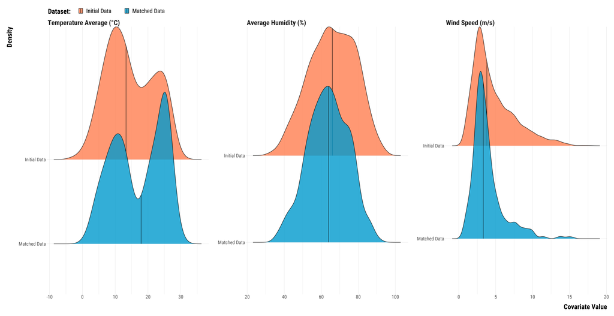

```r
# we select continuous weather variables and store them in a long dataframe
data_continuous_weather_variables <- data_all %>%
  select(temperature_average, wind_speed, humidity_average, dataset) %>%
  pivot_longer(., cols =  c(temperature_average:humidity_average), names_to = "variable", values_to = "values") %>%
  mutate(variable =  factor(variable, levels = c("temperature_average", "humidity_average", "wind_speed")) %>%
           fct_recode(., "Temperature Average (°C)" = "temperature_average", "Average Humidity (%)" = "humidity_average",
                      "Wind Speed (m/s)" = "wind_speed")) %>%
  mutate(dataset = fct_relevel(dataset, "Initial Data", "Matched Data"))

# we plot the density distributions
graph_density_continuous_weather_variables <- ggplot(data_continuous_weather_variables, aes(x = values, y = fct_rev(dataset), fill = fct_rev(dataset))) +
  stat_density_ridges(quantile_lines = TRUE, quantiles = 2, colour = "black", alpha = 0.8) +
  scale_fill_manual(values=c("deepskyblue3", "coral"), guide = guide_legend(reverse = TRUE)) +
  ylab("Density") +
  xlab("Covariate Value") +
  labs(fill = "Dataset:") +
  facet_wrap(~variable, scale = "free", ncol = 3) +
  custom_theme +
  theme(legend.position = "top", legend.justification = "left", legend.direction = "horizontal")

# print the graph
graph_density_continuous_weather_variables
```

We plot the proportion of weather categorical variables for the two datasets

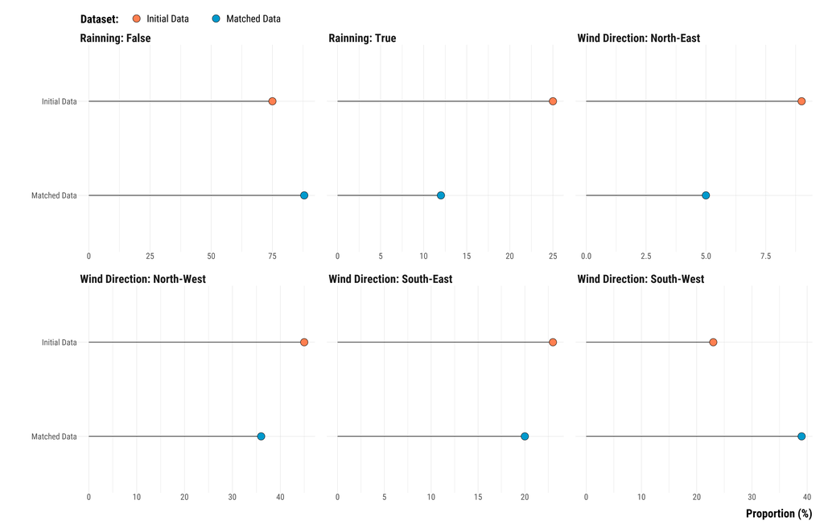

```r
# we select categorical weather variables and store them in a long dataframe
data_categorical_weather_variables <- data_all %>%
  # select relevant variables
  select(wind_direction_categories, rainfall_height_dummy, dataset) %>%
  drop_na() %>%
  # recode the rainfall_height_dummy into true/false
  mutate(rainfall_height_dummy = ifelse(rainfall_height_dummy == 1, "Rainning: True", "Rainning: False")) %>%
  mutate(wind_direction_categories = fct_recode(wind_direction_categories, "Wind Direction: North-East" = "North-East", "Wind Direction: South-East" = "South-East",
                      "Wind Direction: South-West" = "South-West", "Wind Direction: North-West" = "North-West")) %>%
  # transform variables to character
  mutate_all(~ as.character(.)) %>%
  # transform the data to long to compute the proportion of observations for each variable
  pivot_longer(cols = -c(dataset), names_to = "variable", values_to = "values") %>%
  # group by dataset, variable and values
  group_by(dataset, variable, values) %>%
  # compute the number of observations
  summarise(n = n()) %>%
  # compute the proportion
  mutate(freq = round(n / sum(n)*100, 0)) %>%
  # reorder labels of the dataset variable
  ungroup() %>%
  mutate(dataset = fct_relevel(dataset, "Initial Data", "Matched Data"))

# we plot the cleveland dots plots
graph_categorical_weather_variables <-ggplot(data_categorical_weather_variables, aes(x = freq, y = fct_rev(dataset), fill =  fct_rev(dataset))) +
  geom_segment(aes(x = 0, xend = freq, y =  fct_rev(dataset), yend =  fct_rev(dataset))) +
  geom_point(shape = 21, color = "black", size = 8) +
  scale_fill_manual(values=c("deepskyblue3", "coral"), guide = guide_legend(reverse = TRUE)) +
  facet_wrap(~values, scale = "free_x", ncol = 3) +
  ylab("") +
  xlab("Proportion (%)") +
  labs(fill = "Dataset:") +
  custom_theme +
  theme(legend.position = "top", legend.justification = "left", legend.direction = "horizontal")

# print the graph
graph_categorical_weather_variables
```

We combine the `graph_density_continuous_weather_variables` and `graph_categorical_weather_variables` :

```r
# combine plots
graph_weather_three_datasets <- graph_density_continuous_weather_variables / graph_categorical_weather_variables +
  plot_annotation(tag_levels = 'A') & theme(plot.tag = element_text(size = 30, face = "bold"))

# save the plot
ggsave(graph_weather_three_datasets, filename = here::here("3.outputs", "1.figures", "2.analysis_pollution", "1.cruise_experiment", "1.checking_matching_procedure", "graph_weather_two_datasets.pdf"),
       width = 50, height = 40, units = "cm", device = cairo_pdf)
```

We plot the proportions of observations belonging to each day of the week by dataset:

[figure not shown]

```r
# compute the proportions of observations belonging to each day of the week by dataset

data_weekday <- data_all %>%
  mutate(weekday = lubridate::wday(date, abbr = FALSE, label = TRUE)) %>%
  mutate(weekday_en=ifelse(weekday=="lundi", "Monday",ifelse(weekday=="mardi","Tuesday",ifelse(weekday=="mercredi","Wednesday",ifelse(weekday=="jeudi","Thursday",ifelse(weekday=="vendredi","Friday",ifelse(weekday=="samedi","Saturday","Sunday"))))))) %>%
  select(weekday_en, dataset) %>%
  mutate(
    weekday_en = fct_relevel(
      weekday_en,
      "Monday",
      "Tuesday",
      "Wednesday",
      "Thursday",
      "Friday",
      "Saturday",
      "Sunday"
    )
  ) %>%
  pivot_longer(.,-dataset) %>%
  group_by(name, dataset, value) %>%
  summarise(n = n()) %>%
  mutate(proportion = round(n / sum(n) * 100, 0)) %>%
  ungroup() %>%
  mutate(dataset = fct_relevel(dataset, "Initial Data", "Matched Data"))

# we plot the data using cleveland dot plots
graph_weekday <-
  ggplot(
    data_weekday,
    aes(
      x = as.factor(value),
      y = proportion,
      colour = dataset,
      group = dataset
    )
  ) +
  geom_line(size = 2) +
  scale_colour_manual(values = c("coral", "deepskyblue3"),
                      guide = guide_legend(reverse = FALSE)) +
  ggtitle("Day of the Week") +
  ylab("Proportion (%)") +
  xlab("") +
  labs(colour = "Dataset:") +
  custom_theme +
  theme(
    legend.position = "top",
    legend.justification = "left",
    legend.direction = "horizontal"
  )

# we print the graph
graph_weekday
```

We plot the proportions of observations belonging to bank days and holidays by dataset:

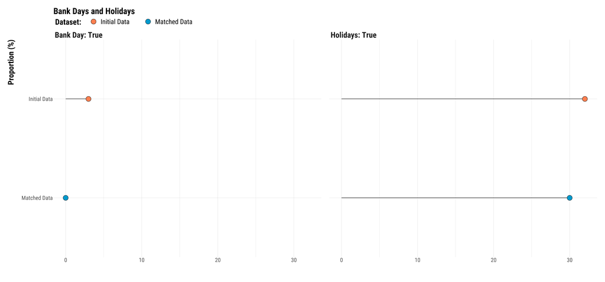

```r
# compute the proportions of observations belonging to bank days and holidays by dataset
data_bank_holidays <- data_all %>%
  select(bank_day_dummy, holidays_dummy, dataset) %>%
  pivot_longer(., -dataset) %>%
  mutate(name = recode(name, bank_day_dummy = "Bank Day", holidays_dummy = "Holidays")) %>%
  group_by(name, dataset, value) %>%
  summarise(n = n()) %>%
  mutate(proportion = round(n / sum(n)*100,0)) %>%
  ungroup() %>%
  mutate(dataset = fct_relevel(dataset, "Data", "Initial Data", "Matched Data")) %>%
  filter(value == 1) %>%
  mutate(name = paste(name, ": True", sep = ""))

# we plot the data using cleveland dot plots
graph_bank_holidays <- ggplot(data_bank_holidays, aes(x = proportion, y = as.factor(dataset), fill = dataset)) +
  geom_segment(aes(x = 0, xend = proportion, y =  fct_rev(dataset), yend =  fct_rev(dataset))) +
  geom_point(shape = 21, colour = "black", size = 8) +
  scale_fill_manual(values=c("coral", "deepskyblue3"), guide = guide_legend(reverse = FALSE)) +
  facet_wrap(~ name) +
  ggtitle("Bank Days and Holidays") +
  ylab("Proportion (%)") +
  xlab("") +
  labs(fill = "Dataset:") +
  custom_theme +
  theme(legend.position = "top", legend.justification = "left", legend.direction = "horizontal")

# we print the graph
graph_bank_holidays
```

We plot the proportions of observations belonging to each month by dataset:

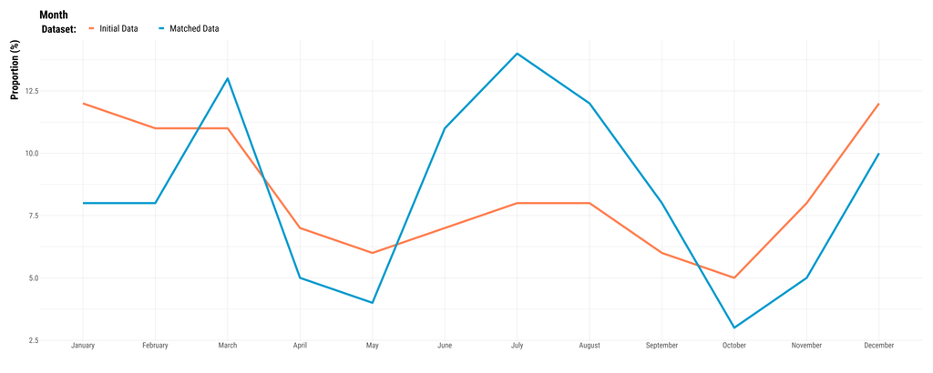

```r
# compute the proportions of observations belonging to each month by dataset
data_month <- data_all %>%
  select(month, dataset) %>%
  mutate(month = recode(month, `1` = "January",
                               `2` = "February",
                               `3` = "March",
                               `4` = "April",
                               `5` = "May",
                               `6` = "June",
                               `7` = "July",
                               `8` = "August",
                               `9` = "September",
                               `10` = "October",
                               `11` = "November",
                               `12` = "December") %>%
           fct_relevel(., "January", "February", "March","April", "May", "June", "July", "August", "September", "October", "November", "December")) %>%
  pivot_longer(., -dataset) %>%
  group_by(name, dataset, value) %>%
  summarise(n = n()) %>%
  mutate(proportion = round(n / sum(n)*100,0)) %>%
  ungroup() %>%
  mutate(dataset = fct_relevel(dataset, "Initial Data", "Matched Data"))


# we plot the data using cleveland dot plots
graph_month <- ggplot(data_month, aes(x = as.factor(value), y = proportion, colour = dataset, group = dataset)) +
  geom_line(size = 2) +
  scale_colour_manual(values=c("coral", "deepskyblue3"), guide = guide_legend(reverse = FALSE)) +
  ggtitle("Month") +
  ylab("Proportion (%)") +
  xlab("") +
  labs(colour = "Dataset:") +
  custom_theme +
  theme(legend.position = "top", legend.justification = "left", legend.direction = "horizontal")

# we print the graph
graph_month
```

We plot the proportions of observations belonging to each year by dataset:

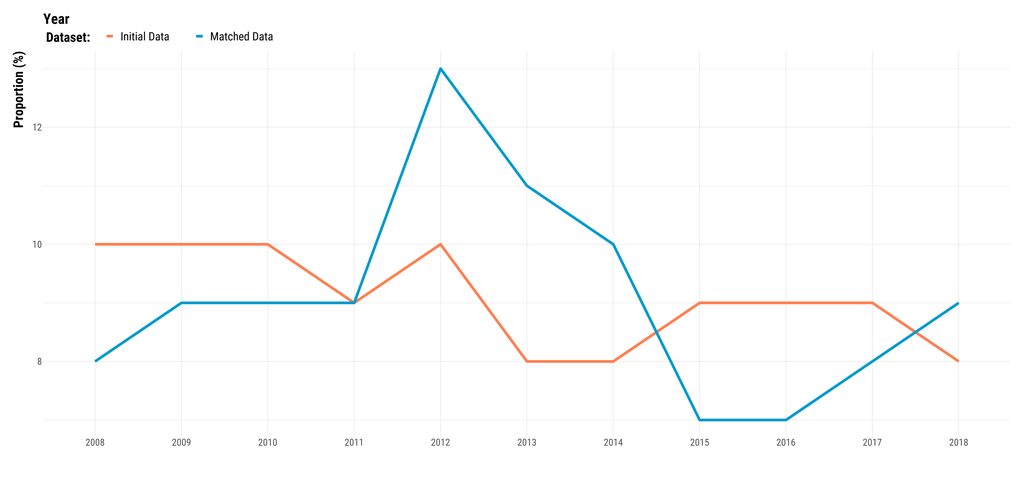

```r
# compute the proportions of observations belonging to each year by dataset
data_year <- data_all %>%
  select(
         year, dataset) %>%
  pivot_longer(., -dataset) %>%
  group_by(name, dataset, value) %>%
  summarise(n = n()) %>%
  mutate(proportion = round(n / sum(n)*100,0)) %>%
  ungroup() %>%
  mutate(dataset = fct_relevel(dataset, "Initial Data", "Matched Data"))


# we plot the data using cleveland dot plots
graph_year <- ggplot(data_year, aes(x = as.factor(value), y = proportion, colour = dataset, group = dataset)) +
  geom_line(size = 2) +
  scale_colour_manual(values=c("coral", "deepskyblue3"), guide = guide_legend(reverse = FALSE)) +
  ggtitle("Year") +
  ylab("Proportion (%)") +
  xlab("") +
  labs(colour = "Dataset:") +
  custom_theme +
  theme(legend.position = "top", legend.justification = "left", legend.direction = "horizontal")

# we print the graph
graph_year
```

We combine all plots for calendar variables:

```r
# combine plots
graph_calendar_three_datasets <- (graph_weekday + graph_bank_holidays) / (graph_month + graph_year) +
  plot_annotation(tag_levels = 'A') & theme(plot.tag = element_text(size = 30, face = "bold"))

# save the plot
ggsave(graph_calendar_three_datasets, filename = here::here("3.outputs", "1.figures", "2.analysis_pollution", "1.cruise_experiment", "1.checking_matching_procedure", "graph_calendar_two_datasets.pdf"),
       width = 80, height = 40, units = "cm", device = cairo_pdf)
```